# 52414 - lab 1

52414

4/4/2020

# *Lab 1: Basic Data Wrangling*

**Contents**:

- Q0) Submission Instructions
- Q1) Data Preparation and Manipulation
- Q2) Analysis of Daily New Corona Cases and Deaths
- Q3) Preparing and Analyzing the World Bank Data
- Q4) Joining the Datasets
- Q5) Open Question

### Submission Instructions

This lab will be submitted in pairs using GitHub (if you don’t have a pair, please contact us).  
Please follow the steps in the [GitHub-Classroom Lab 1](https://classroom.github.com/g/oSZNtHq4) to create your group’s Lab 1 repository.  
**Important: your team’s name must be `FamilyName1_Name1_and_FamilyName2_Name2`**.  
You can collaborate with your partner using the git environment; You can either make commits straight to master, or create individual branches (recommended). However, once done, be sure to merge your branches to master - you will be graded using the most recent master version - your last push and merge before the deadline.  
**Please do not open/review other peoples’ repositories - we will be notified by GitHub if you do.**

Your final push should include this Rmd file (with your answers) together with the html file that is outputted automatically by knitr when you knit the Rmd. Anything else will be disregarded. In addition, please adhere to the following file format:  
`Lab_2_FamilyName1_Name1_and_FamilyName2_Name2.Rmd/html`

For plots and graphs, make sure you add proper titles, labels, and legends/colors (if you have more than 1 variable on the y-axes). Your plots should clearly convey the information you are trying to communicate.  
Please write your code in a clear and concise way, with an emphasis on reproducibility. Use markdown to provide explanations before/after the code blocks.

## A Deeper Dive Into John’s Hopkins Corona Database

The John’s Hopkins Novel Corona Virus (COVID-19) epidemiological data is compiled by the Johns Hopkins University Center for Systems Science and Engineering (JHU CCSE) from various sources.  
The dataset contains data since 22nd of January 2020. For the data and more information about it, please visit [here](https://data.humdata.org/dataset/novel-coronavirus-2019-ncov-cases).

In this lab you will pick up where we left in lecture 2 and analyze the Corona cases and deaths data.

### Q1

### Data Preparation and Manipulation

(25 points)

1. We first prepare and aggregate the data.
1. First, load the `Corona Confirmed Cases Narrow`, the `Corona Confirmed Deaths Narrow`, and the `Corona Confirmed Recovered Narrow` datasets directly from the John’s Hopkins website.  
   The type of the `Date` variable should be date type. (2 pts)
2. Create new data-frames named `cases.agg`, `deaths.agg`, and `recovered.agg` which aggregate the `sum` of Corona cases, deaths, and recovered respectively over the different countries’ provinces. To do this, aggregate `Value` using only the country and date features, ignoring all other features (similarly to what has been shown in `lecture 2`).  
   To achieve the aggregation use the `aggregate` function. In addition, order the data-frame first by Country and then by Date (increasing order). The columns of each of the two resulting data-frames should be `Country.Region, Date, Value`. (5pts)
3. Repeat (b) using `tidyverse` and the pipe. Show that the outputs from the two methods are the same. (5pts)
4. Using the last day of March as a reference, create a single stacked bar-plot that visualizes the top 10 countries in terms of their Corona cases, and their respected Corona deaths and recovered cases stacked on top of the current sick people in three different colors (each stack should add up to total cases). Make sure that the first stack shows the number of confirmed Corona sick people (`sick = cases - deaths - recovered`). Each stacked bar should represent a country. Please use the barplot base R function to create this plot. I recommend everyone to read the help documentation for barplot ; go over the expected input, and the different parameters. What is the biggest issue with the information presented in this plot? (13pts)

**Solution:**

```r
# loading the data frames:
confirmed <- read.csv(file = url_cases, header = T, comment.char = "#")
recovered <- read.csv(file= url_recovered, header = T, comment.char = "#")
deaths <- read.csv(file= url_deaths, header = T, comment.char = "#")

#(a)- Date type for the date culomns:
confirmed$Date <- as.Date(confirmed$Date)
deaths$Date <- as.Date(deaths$Date)
recovered$Date <- as.Date(recovered$Date)

msg <- "The type of the Date column in table"
dataframes_names <- c("confirmed", "recovered", "deaths")
dataframes <- c(confirmed, recovered, deaths)
for(i in 1:3)
{
  cat(msg, dataframes_names[i], "is:", class(dataframes[[5+ 10*(i-1)]]), "\n")
  }
```

```
## The type of the Date column in table confirmed is: Date
## The type of the Date column in table recovered is: Date
## The type of the Date column in table deaths is: Date
```

```r
#(b) - ordering the aggregated tables by date and country
cases.agg <- aggregate(Value ~ Country.Region + Date, data = confirmed, FUN = sum)
deaths.agg <- aggregate(Value ~ Country.Region + Date, data = deaths, FUN = sum)
recovered.agg <- aggregate(Value ~ Country.Region + Date, data = recovered, FUN = sum)

# ordering each aggregated table by country and date:
cases.agg <- cases.agg[order(cases.agg$Date),]
cases.agg <- cases.agg[order(cases.agg$Country.Region),]

recovered.agg <- recovered.agg[order(recovered.agg$Date),]
recovered.agg <- recovered.agg[order(recovered.agg$Country.Region),]

deaths.agg <- deaths.agg[order(deaths.agg$Date),]
deaths.agg <- deaths.agg[order(deaths.agg$Country.Region),]

#(c) - ordering using dplyr (tidyverse) and pipe, showing same results
library("dplyr")

# we make copies of the unorginized aggregated tables:
cases.agg_copy <- aggregate(Value ~ Country.Region + Date, data = confirmed, FUN = sum)
deaths.agg_copy <- aggregate(Value ~ Country.Region + Date, data = deaths, FUN = sum)
recovered.agg_copy <- aggregate(Value ~ Country.Region + Date, data = recovered, FUN = sum)

# we orginize with the pipe and tidyverse:
cases.agg_tidy <- cases.agg_copy %>% arrange(Country.Region, Date)
deaths.agg_tidy <- deaths.agg_copy %>% arrange(Country.Region, Date)
recovered.agg_tidy <- recovered.agg_copy %>% arrange(Country.Region, Date)
```

[output not shown]

[output not shown]

[output not shown]

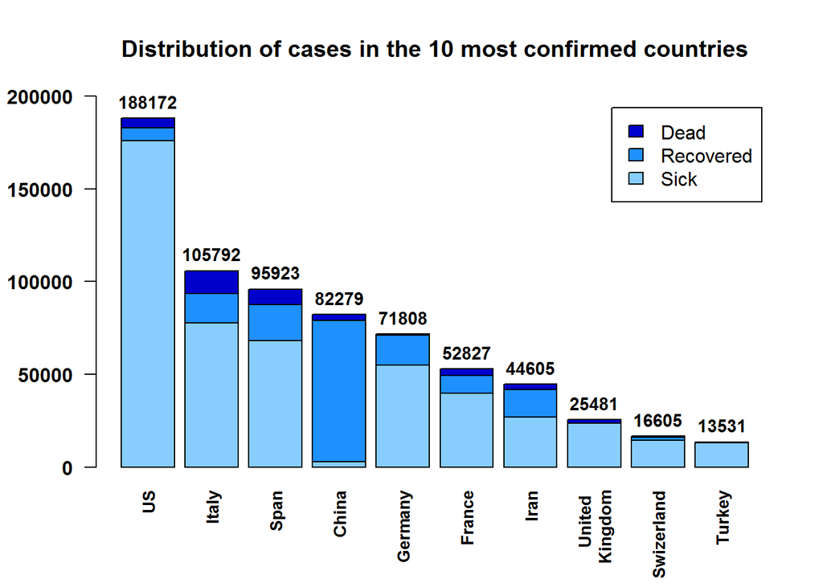

```r
#(d) -  plotting a single stacked bar-plot:

# we filter each table by last day of March:
cases_end_march <- filter(.data = cases.agg, Date == "2020-03-31")
deaths_end_march <- filter(.data = deaths.agg, Date == "2020-03-31")
recovered_end_march <- filter(.data = recovered.agg, Date == "2020-03-31")

# we add to the original table we work on verctors of deaths and recovered on March 31st:
cases_end_march$Deaths <- deaths_end_march$Value
cases_end_march$Recovered <- recovered_end_march$Value
# we slice only the last 10 countries with the highest number of CONFIRMED CASES:
cases_end_march <- arrange(.data = cases_end_march, desc(Value))[c(1:10),]

# memory cleaning...
rm(deaths_end_march)
rm(recovered_end_march)
rm(cases.agg_copy)
rm(recovered.agg_copy)
rm(deaths.agg_copy)

# create a sick column:
cases_end_march$Sick <- (cases_end_march$Value)-(cases_end_march$Deaths)-(cases_end_march$Recovered)

# creating the stacked-bars plot:

# creating a matrix of numbers to pile up as stacked bars:
numbers_matrix <- as.matrix(data.frame(cases_end_march$Sick,cases_end_march$Recovered, cases_end_march$Deaths))
# plotting:
title_main <- "Distribution of cases in the 10 most confirmed countries"

subtitle <- "Confirmed sick, recovered and dead on the last day of March"

colors_for_plot <- c("skyblue1", "dodgerblue1", "mediumblue")

# we write the countries manualy so that UK could have 2 lines:
countries <- c("US", "Italy", "Span", "China", "Germany",
               "France", "Iran","United \nKingdom", "Swizerland", "Turkey")

stacked_plot<- barplot(height = t(numbers_matrix), names.arg = countries,
                       las = 2,  ylim = c(0 , 200000), main = title_main,
                       beside = F, col= colors_for_plot,  font = 2,
                       cex.names = 0.85, legend.text = c("Sick", "Recovered", "Dead"))

text(x = stacked_plot, y= cases_end_march$Value + 9000, cex = 0.9, xpd= T,
     label = cases_end_march$Value, font = 2)
```

### **The biggest issue with the information presented in this plot, in our opinion:**

**We think that the biggest issue with the information presented in this plot, is that China seems to have a fewer number of cases than the US, and seems to report a large number of recovered civilians. We find it hard to believe the numbers, and to accept that most of the people in China have recovered, compared to what we can see in the news.**

### Q2

### Analysis of Daily New Corona Cases and Deaths

20 points

The two datasets (Corona Cases and Deaths) register the value of cases and deaths, respectively, as a cumulative sum for each day. In this question we would like to understand the daily differences between consecutive days.

1. Add a new column named `Diff` to both the `cases.agg` and the `deaths.agg` data-frames. This new column should register the daily `Value` difference for each country. In other words, the `Diff` column shows how many new cases/deaths each country incurs every day. Hint - diff must be per country. (7pts)
2. Find the top 10 instances of country and date combinations with the greatest absolute number of new daily Corona cases and deaths (separately). Print the result in a descriptive format. (5pts)
3. In one figure, plot Italy’s new daily Corona cases AND deaths as a function of Date. Choose the plot type you think that makes the most sense. (3pts)
4. Plot the same graph as in (c), but this time plot the number of new cases on the logarithm scale. What can we learn? (5pts)

**Solution:**

```r
#(a) inserting a difference vector to the cases and deaths aggregated tables:

# we first add zeros, so everytime we switch a country, the difference shall start again from zero.
# some countries do not start with zero cases, but we cannot decide how many added in the last day.

cases.agg$Diff <- 0
deaths.agg$Diff <- 0

for(i in 1 : (length(cases.agg$Value)-1) )
{
  ifelse(test = (cases.agg$Country.Region[i] == cases.agg$Country.Region[i+1]) ,
         cases.agg$Diff[i+1] <- (cases.agg$Value[i+1]-cases.agg$Value[i]),
         cases.agg$Diff[i+1] <- cases.agg$Diff[i+1])

   ifelse(test = (deaths.agg$Country.Region[i] == deaths.agg$Country.Region[i+1]) ,
         deaths.agg$Diff[i+1] <- (deaths.agg$Value[i+1]-deaths.agg$Value[i]),
         deaths.agg$Diff[i+1] <- deaths.agg$Diff[i+1])
}

#(b) 10 combination of country and date, for which the daily increase was highest:
cases.agg_copy <- dplyr::select(.data = cases.agg, colnames(cases.agg))
deaths.agg_copy <- dplyr::select(.data = deaths.agg, colnames(deaths.agg))

cases.agg_copy <- arrange(.data = cases.agg_copy, desc(Diff))
cases.agg_copy <- dplyr::select(.data = cases.agg_copy,Country.Region, Date, Diff)[1:10 ,]

deaths.agg_copy <-arrange(.data = deaths.agg_copy, desc(Diff))
deaths.agg_copy <- dplyr::select(.data = deaths.agg_copy, Country.Region, Date, Diff)[1:10 ,]
```

**For confirmed cases:**

```
##    Country.Region       Date  Diff
## 1              US 2020-04-24 36188
## 2              US 2020-04-09 34126
## 3              US 2020-04-10 33755
## 4              US 2020-04-04 33283
## 5              US 2020-04-25 32796
## 6              US 2020-04-18 32491
## 7              US 2020-04-17 32114
## 8              US 2020-04-03 31745
## 9              US 2020-04-08 31533
## 10             US 2020-04-16 31242
```

**For confirmed deaths:**

```
##    Country.Region       Date Diff
## 1              US 2020-04-17 2584
## 2              US 2020-04-15 2472
## 3              US 2020-04-21 2427
## 4              US 2020-04-14 2392
## 5              US 2020-04-18 2342
## 6              US 2020-04-22 2326
## 7              US 2020-04-23 2312
## 8              US 2020-04-07 2297
## 9              US 2020-04-25 2262
## 10             US 2020-04-16 2093
```

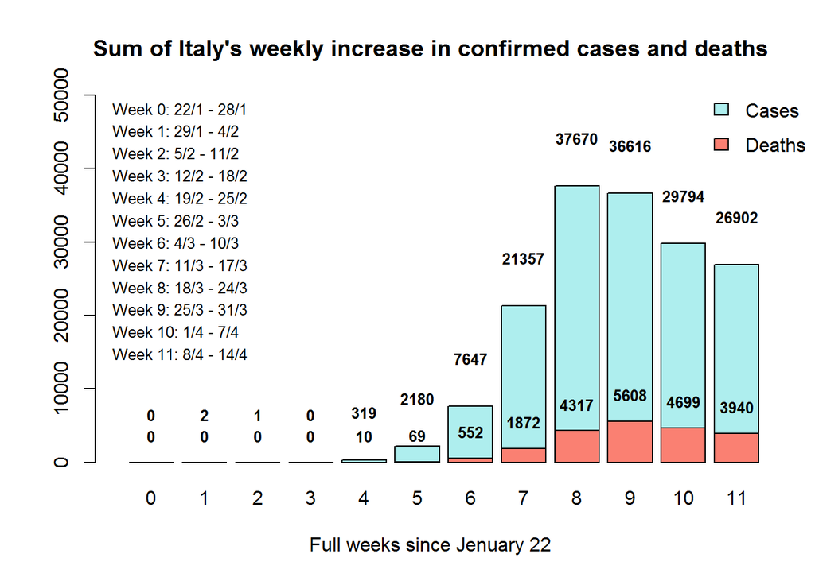

```r
#(c) - plotting Italy's daily increase in confirmed cases and deaths:

#creating the relevant data for our plot:
increase_cases <- cases.agg %>% filter(Country.Region == "Italy") %>% select(Date, Diff)
increase_cases$index <- as.factor(floor(((increase_cases$Date)-as.Date("2020-01-22"))/7))
height_cases <- aggregate(Diff ~ index, data = increase_cases, FUN = sum)[1:12,]

increase_deaths <- deaths.agg %>% filter(Country.Region == "Italy") %>% select(Date, Diff)
increase_deaths$index <- as.factor(floor(((increase_deaths$Date)-as.Date("2020-01-22"))/7))
height_deaths <- aggregate(Diff ~ index, data = increase_deaths, FUN = sum)[1:12,]

bp <- barplot(height = height_cases$Dif, ylim = c(0, 50000), xlim = c(0, 14) ,
              col = "paleturquoise2",
              main = "Sum of Italy's weekly increase in confirmed cases and deaths",
              xlab = "Full weeks since Jenuary 22",
              names.arg = height_cases$index,legend = T)

barplot(height_deaths$Diff, add  = T, col = "salmon", legend= T)

weeks_legend <- c("Week 0: 22/1 - 28/1","Week 1: 29/1 - 4/2", "Week 2: 5/2 - 11/2",
                  "Week 3: 12/2 - 18/2", "Week 4: 19/2 - 25/2", "Week 5: 26/2 - 3/3"
                  ,"Week 6: 4/3 - 10/3","Week 7: 11/3 - 17/3","Week 8: 18/3 - 24/3",
                  "Week 9: 25/3 - 31/3","Week 10: 1/4 - 7/4", "Week 11: 8/4 - 14/4")

legend(x = 13 ,y = 52000, legend = c("Cases", "Deaths"), fill = c("paleturquoise2", "salmon"), bty = "n",
       y.intersp = 1.5, xpd = T)

legend(x = -0.8, y = 51000, legend = weeks_legend ,bty  = 'n',
       y.intersp = 1.2, xpd = T, cex = 0.8)

text(x= bp,y=  height_cases$Diff + 6500, labels = height_cases$Diff, xpd = T, font = 2, cex = 0.8)
text(x= bp,y=  height_deaths$Diff + 3600, labels = height_deaths$Diff, xpd = T, font = 2,cex = 0.8)
```

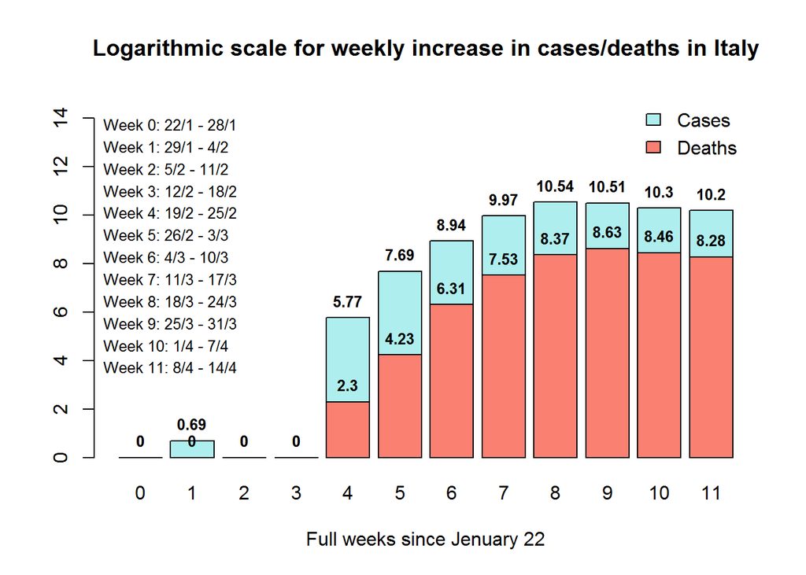

```r
#(d) - logrithmic scale for the last graph:

# creating the log vectors:
log_cases <- log(height_cases$Dif)
log_deaths <- log(height_deaths$Diff)
for(i in 1: length(log_cases))
{
  ifelse(log_cases[i] == -Inf, log_cases[i]<- 0, log_cases[i]<-log_cases[i])
  ifelse(log_deaths[i] == -Inf, log_deaths[i]<- 0, log_deaths[i]<-log_deaths[i])
}
bp_log <- barplot(height = log_cases , ylim = c(0, 15),
              col = "paleturquoise2",
              main = "Logarithmic scale for weekly increase in cases/deaths in Italy",
              xlab = "Full weeks since Jenuary 22",
              names.arg = height_cases$index,legend = T)

barplot(log_deaths, add  = T, col = "salmon", legend= T)

weeks_legend <- c("Week 0: 22/1 - 28/1","Week 1: 29/1 - 4/2", "Week 2: 5/2 - 11/2",
                  "Week 3: 12/2 - 18/2", "Week 4: 19/2 - 25/2", "Week 5: 26/2 - 3/3"
                  ,"Week 6: 4/3 - 10/3","Week 7: 11/3 - 17/3","Week 8: 18/3 - 24/3",
                  "Week 9: 25/3 - 31/3","Week 10: 1/4 - 7/4", "Week 11: 8/4 - 14/4")

legend(x = 12 ,y = 15, legend = c("Cases", "Deaths"), fill = c("paleturquoise2", "salmon"), bty = "n",
       y.intersp = 1.2, xpd = T)

legend(x = -0.8, y = 14.6, legend = weeks_legend ,bty  = 'n',
       y.intersp = 1.2, xpd = T, cex = 0.8)

text(x= bp_log, y=  log_cases + 0.7 , labels = round(log_cases, 2) , xpd = T, font = 2, cex = 0.8)
text(x= bp_log, y=  log_deaths + 0.7, labels = round(log_deaths,2) , xpd = T, font = 2,cex = 0.8)
```

#### What can we learn from applying log on the weekly increase scale:

**We think that the logarithmic scale can distinguish weeks in which there was a linear growth scale or exponential growth scale. Since $\ln({e^{cx}}) = cx$ the linear growth part is respective to an exponential growth, and the part where we can spot quite moderate (to almost none) changes, we can assume to look at linear growth, since $\ln(C) = C'$ for $C, C' \in \mathbb{R}$**

### Q3

### Preparing and Analyzing the World Bank Data

25 points

1. Rename the columns of `eco_data`: `country,S_country,feature,feature_code,Y2018V,Y2019V`. (2pts)
2. Create a new `eco` data-frame whose dimensions are $N \times 11$, where `N` is the number of countries. The first column should include the names of the countries in `eco_data.`  
   The rest of the columns should be the features with their respective values in `eco_data` for each country from 2018. Print the head of the new data-frame.(8pts).  
   In other words, in this question you are asked to create a new eco data-frame whose dimensions are $N \times 11$, where N is the number of countries (the first column should include the names of the countries in `eco_data`). The rest of the columns should be the features with their respective values in eco_data for each country from 2018. Print the head of the new data-frame. You may delete rows with NA as a country value only.
3. Select and rename the following columns: `country` as country, `GDP(US currency)` as GDP, `Population ages 65 and above (% of total population)` as pop65, `Population in the largest city (% of urban population)` as pop_city_ratio, `Population, total` as pop_total columns . (2pts)
4. Show a table of the five countries with the highest per capita GDP in 2018.  
   Next (considering all countries), plot the % of population over 65 vs. log of GDP per capita in 2018, after excluding the 10% countries with the lowest GDP per capita. Using `lm` and `abline`, add a regression line to the plot. What is your conclusion? (13 pts)

**Solution:**

```r
#loading the `eco_data`:
eco_data <- read.csv(url("https://raw.githubusercontent.com/DataScienceHU/DataAnalysisR_2020/master/data/economic_data.csv"))
```

```r
#(a) - renaming the table's columns names:
colnames(x = eco_data) <- c("country", "S_country", "feature","feature_code","Y2018V","Y2019V")

#(b) - creating the new data frame:

# creating the data frame:
eco <- as.data.frame(matrix(nrow = 264, ncol = 11))

#naming the columns:
colnames(eco)<- append(c("country"),as.character(eco_data$feature[1:10]))

#extracting data from the original data frame:
eco$country <- as.character(unique(eco_data$country)[1:264])
for(i in 2:11)
{
  eco[,i] <- eco_data$Y2018V[eco_data$feature ==  colnames(eco)[i]]
}

# replacing ".." marks with NA:
for(i in 1:264)
  {
  for(j in 1:11)
    {
    ifelse(as.character(eco[i,j]) == "..", eco[i,j]<- NA, eco[i,j]<-eco[i,j])
    }
}

print(head(eco))
```

```
##          country GDP (current US$) GDP (constant LCU)
## 1    Afghanistan  19362969582.3643   511432475534.156
## 2        Albania   15102500898.238      1513259270000
## 3        Algeria   173757952824.25   6123376375970.86
## 4 American Samoa         636000000          608000000
## 5        Andorra  3236543909.34844         2002840000
## 6         Angola   105750987618.63      1552771000000
##   GDP, PPP (current international $)
## 1                   72672245387.0863
## 2                   38306694289.2319
## 3                   653771569286.319
## 4                               <NA>
## 5                               <NA>
## 6                   198795526982.065
##   Unemployment, female (% of female labor force) (modeled ILO estimate)
```

[output cut: 41 more lines]

```r
#(c) - selecting and renaming:

eco_renamed <- dplyr::select(.data = eco, "Country" = country, "GDP"=`GDP (current US$)`,
                             "pop65" = `Population ages 65 and above (% of total population)`,
                             "pop_city_ratio" = `Population in the largest city (% of urban population)`,
                             "pop_total" = `Population, total`)

#(d)

# adding the 'GDP per capita' and log of 'GDP per capita':
eco_renamed$"GDP_per_capita" <- 0
eco_renamed$"log_GDP_per_capita" <- 0

# converting the values of the existing table into numeric type:
for(i in 2:7){
  eco_renamed[,i] <- as.numeric(as.character(eco_renamed[,i]))
}

# creating the division vector, and its log, for wherever it's possible and valid:
for(i in 1:264)
{
    ifelse(is.na(eco_renamed$pop_total[i])|is.na(eco_renamed$GDP[i]), eco_renamed$GDP_per_capita[i] <- NA,
           eco_renamed$GDP_per_capita[i] <- ((eco_renamed$GDP[i])/(eco_renamed$pop_total[i])))

    ifelse((is.na(eco_renamed$GDP_per_capita[i])|(eco_renamed$GDP_per_capita[i] == 0)),
            eco_renamed$log_GDP_per_capita[i] <- NA ,
           eco_renamed$log_GDP_per_capita[i] <- log(eco_renamed$GDP_per_capita[i]))
}

#orginizing the new table by the GDP per capita, while cutting the lowest 10% of the GDP per capita:
cut_off<- round(0.1*length(eco_renamed$GDP_per_capita))
index <- length(eco_renamed$GDP_per_capita) - cut_off
eco_renamed <- arrange(.data = eco_renamed, desc(GDP_per_capita))[1:index ,]

#(d) - (1): 5 countries with top GDP per capita:
print(head(eco_renamed, n=5))
```

```
##            Country          GDP    pop65 pop_city_ratio pop_total
## 1           Monaco   7184844193       NA             NA     38682
## 2       Luxembourg  70885325883 14.18315             NA    607728
## 3 Macao SAR, China  55084050790 10.48420      100.00000    631636
## 4      Switzerland 705140354166 18.62322       21.81049   8516543
## 5           Norway 434166615432 17.04922       23.15809   5314336
##   GDP_per_capita log_GDP_per_capita
## 1      185741.28           12.13211
## 2      116639.89           11.66685
## 3       87208.54           11.37606
## 4       82796.55           11.32414
## 5       81697.25           11.31078
```

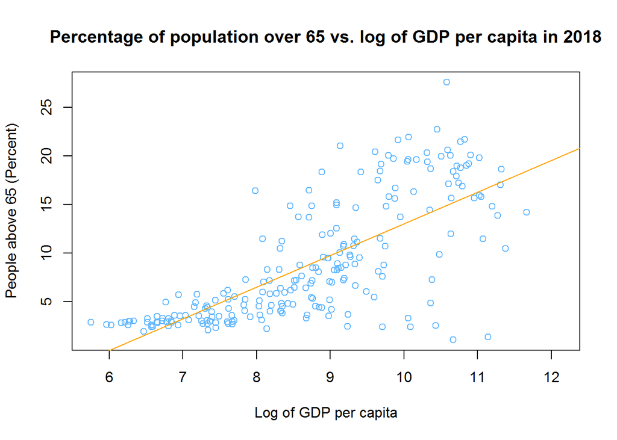

```r
#(d) - (1)ploting the log:
plot_log <- plot(x = eco_renamed$log_GDP_per_capita, y = eco_renamed$pop65, ylab = "People above 65 (Percent)",
     xlab = "Log of GDP per capita", main = "Percentage of population over 65 vs. log of GDP per capita in 2018",
     col = "steelblue1")

#coefs <- (lm(eco_renamed$log_GDP_per_capita ~ eco_renamed$pop65))$coefficients
abline(lm(eco_renamed$pop65 ~ eco_renamed$log_GDP_per_capita ), col = "orange")
```

#### Our conclusion about the graph:

**After applying $ln(x)$ on the ‘GDP per capita’ culomn, we can see that the curve is somehow flattened. That can tell us the the GDP per capita had a certain exponentian growing pattern, and after applying $ln(x)$ we can see that what we get is linear in a way. Since the scattering after 9 (a-axis) is greater, we can say that our linearity is not absulote, but an approximation. That said, we can conclude that there’s a positive corelation between the percent of people at age 65 (and above), and the GDP per capita, and that could indicate that the older you get, the more GDP you probably make. According to this data we can assume that older people are more experienced, and therefore, can make more GDP easier, probably because they know all the rules, and the right people.**

### Q4

### Joining the Datasets

20 points

1. Join the `deaths.agg`, `cases.agg`, and `recovered.agg` into one data-frame called `corona`.(5pts)
2. Join the `corona` and `eco` data-frames in a way that will keep the most information regarding the data (but not full join).  
   Make sure that no essential data is thrown away (show this). (3pts)
3. Create new columns of normalized `cases`, `deaths`, and `recovered` so they will show the number of cases per 100,000 people for each country.  
   Using the last day of March as a reference, create a single stacked bar plot that visualizes the top 10 countries in terms of normalized Corona cases, and their respected normalized Corona deaths and recovered, as done in Q1.  
   how is it different from the graph before normalization? (5pts)
4. Using the last day of March as a reference, create a scatter-plot of normalized deaths and cases vs. `pop65`. Limit the plot to show only countries with 15% or more of `pop65`.  
   In addition, color the outliers( pop65>24, norm100K_deaths>15) in that plot in red and add to the plot their country names (7pts)

**Solution:**

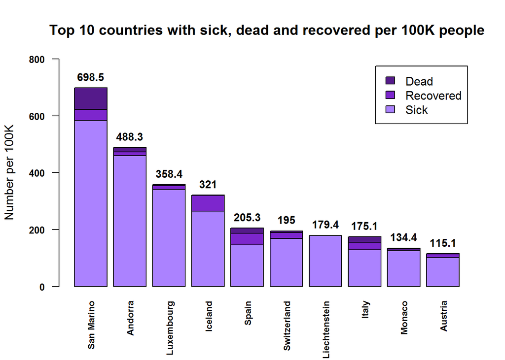

```r
#(a) - joining tables, and creating 'corona':

corona <- select(.data = cases.agg, "country" = Country.Region, Date, "Value (cases)" = Value, "Diff (cases)" = Diff)
corona <- mutate(.data = corona, "Value (deaths)" = deaths.agg$Value,"Diff (deaths)" = deaths.agg$Diff,
                 "Value (recovered)" = recovered.agg$Value)
corona$country <- as.character(corona$country)

#(b) - merging corona and eco, while losing as least information as possible from the data:

# eco is the biggest table, and it contains the countries of corona, plus some rows, regarding islands \ and economical issues (not countries)
# Therefore, we'd cut out anything that is not a proper country, while correcting names of the same places that dont match.

eco$country <- as.character(eco$country)
eco <- eco[1:216,]
# many countries were in both tables but didn't share the exact name. we'll make sure we have a mtching name, so we can join the tables according to the intersecting countries:

countries_to_fix <- c("Bahamas", "Brunei", "Congo (Brazzaville)", "Congo (Kinshasa)", "Czechia", "Egypt","Gambia",
                      "Iran", "Korea, South","Kyrgyzstan","Laos", "Russia","Slovakia", "Saint Kitts and Nevis",
                      "Saint Lucia","Saint Vincent and the Grenadines", "Syria", "US", "Venezuela", "Yemen")

indices_to_fix <- c(14, 29, 45, 46, 53, 59, 72, 92, 105,108,109,162,174,182,183,185,190, 207, 211,215)

for(i in 1:length(countries_to_fix))
{
  eco$country[indices_to_fix[i]] <- countries_to_fix[i]
}

#(a) - (1) creating the joint table:
corona_eco_joint <- inner_join(x = corona, y= eco, by= "country")

# we correct the names of the columns as we did in the last question:
names_to_correct <- c("GDP","pop65", "pop_city_ratio", "pop_total")
indices_to_fix_names <- c(8, 17, 15, 14)

for(i in 1:4)
  {
  colnames(corona_eco_joint)[indices_to_fix_names[i]] <- names_to_correct[i]
}

corona_eco_joint$pop_total <- as.numeric(as.character(corona_eco_joint$pop_total))

#(b) -
# (1) - creating normalized columns per 100k people:
corona_eco_joint$"Sick" <- corona_eco_joint$`Value (cases)` - corona_eco_joint$`Value (deaths)` - corona_eco_joint$`Value (recovered)`
corona_eco_joint$"Cases normalized" <-  100000*((corona_eco_joint$`Value (cases)`)/(corona_eco_joint$pop_total))
corona_eco_joint$"Deaths normalized" <- 100000*((corona_eco_joint$`Value (deaths)`)/(corona_eco_joint$pop_total))
corona_eco_joint$"Recovered normalized" <- 100000*((corona_eco_joint$`Value (recovered)`)/(corona_eco_joint$pop_total))
corona_eco_joint$"Sick normalized" <- 100000*((corona_eco_joint$Sick )/(corona_eco_joint$pop_total))

# (2) - single stacked bar plot for the 10 countries highest in normalized cases at the end of march:

joint_end_march <- corona_eco_joint %>% filter(Date == "2020-03-31")
joint_end_march <- arrange(.data = joint_end_march, desc(`Cases normalized`))[1:10,]

# in order to make a stacked barplot we have to create a transposed matrix again:

normalized_matrix <- t(as.matrix(data.frame(joint_end_march$`Sick normalized`,
                                          joint_end_march$`Recovered normalized`,
                                          joint_end_march$`Deaths normalized`)))
#cosmetic changes:
country_names <- joint_end_march$country
colors_normalized <- c("mediumpurple1", "purple3", "purple4")

#the graph:
stack_plot <- barplot(height = normalized_matrix, beside = F, names.arg = country_names,
                      cex.names = 0.75, las = 2, ylim = c(0, 800),
                      cex.axis = 0.8, main = "Top 10 countries with sick, dead and recovered per 100K people",
                      ylab = "Number per 100K", legend.text = c("Sick", "Recovered", "Dead"),
                      col = colors_normalized, font = 2)

text(x = stack_plot, y= joint_end_march$`Cases normalized` + 40, cex = 0.9, xpd= T,
     label = round(joint_end_march$`Cases normalized`, 1), font = 2)
```

#### 4.c: Difference between a normalized graph and a normal one:

**As opposed to the original cases values, the normalized cases per 100k helps distinguish the relative quantity per capita in each coutry. If we didn’t normalize the cases, we’d probably get a list of the biggest and most crowded countries, like US or China (we checked, and we did). normalizing the nimber of cases per 100k help see how “hard” each country was affected, relative to its own scale. Relatively to their rather small population, we can observe that places like San marino or Iceland are highly affected by the corona, but that knowledge could be easily missed if we dont normalize.**

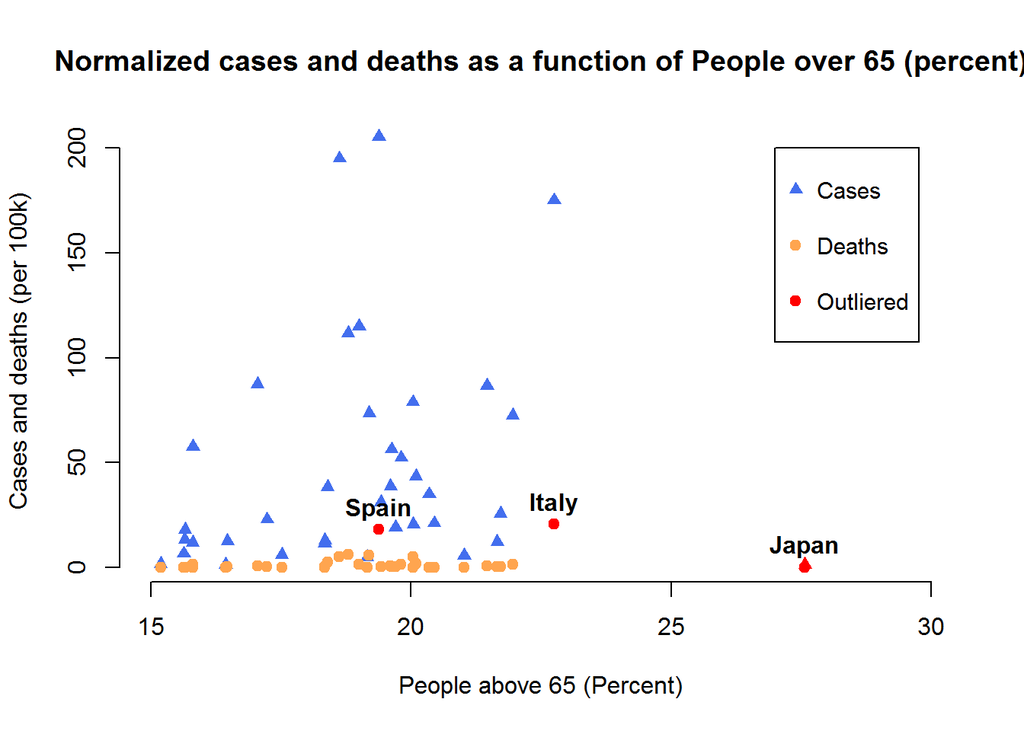

```r
#(d) - scatter plot

# we create a table of the end of march for the plot we have to draw:

joint_end_march_new <- filter(.data = corona_eco_joint , Date == "2020-03-31", as.numeric(as.character(pop65)) >= 15)
joint_end_march_new <- arrange(.data = joint_end_march_new, desc(pop65))
joint_end_march_new$pop65 <- as.numeric(as.character(joint_end_march_new$pop65))

# the plot of the normalized cases VS pop65:
plot(y = joint_end_march_new$`Cases normalized`, x = joint_end_march_new$pop65, pch= 17,
     col = ifelse(joint_end_march_new$pop65 > 24, "red", "royalblue2") ,
      xlab = "People above 65 (Percent)", main = "Normalized cases and deaths as a function of People over 65 (percent)",
     ylab = "Cases and deaths (per 100k)", frame.plot=FALSE,
     xlim = c(15,30))

# adding the point of the normalized deaths VS pop65:
points(y = joint_end_march_new$`Deaths normalized`, x = joint_end_march_new$pop65, pch= 19,
     col = ifelse((joint_end_march_new$pop65 > 24) |(joint_end_march_new$`Deaths normalized` > 15) , "red", "tan1"))

# adding a legent and text for the outliers points that exceed 24 at pop 65:

legend(x = 27, y = 200, legend = c("Cases","Deaths" ,"Outliered") ,pch = c(17,19,19),
       col = c("royalblue2","tan1", "red"),
       bty  = 'o', y.intersp = 2, xpd = T, cex = 0.95)

text(x = joint_end_march_new$pop65, font =2,
        y= joint_end_march_new$`Deaths normalized` + 10,
     label = ifelse((joint_end_march_new$pop65 > 24) |(joint_end_march_new$`Deaths normalized` > 15),
                    joint_end_march_new$country, NA))
```

### Q5

### Open Question

10 points

Write an interesting research question regarding the Corona outbreak and then follow the steps to answer it using tables and plots. You can use the loaded datasets or any other dataset you find as long as you add the data file to your `lab1` repository so it can be loaded directly from a `url` (e.g. the World Bank). This question will be graded based on creativity, originality, and the novelty of the analysis.

**Solution:**

#### Research question: Do infrastructures (Electricity, phone, health system) are factors of dealing with the corona outbreak? How big is their influence?

#### Hypothesis: We assume that having good based infrastructures can improve the way a country can deal with a pandemic outbreak:

- **Phones**: contribute to data spreading and communicating.
- **Electricity**: contributes to working from home, and staying home, while minimizing the need to go outside.
- **Health system**: assuming corona virus will every country eventually, we’d like to assume that a well-prepared health system will deal better with the outbreak.

**We’ll look at the first day of March as a reference, assuming that day is somehow balanced between outbreak and knowledge about the virus, which means, we believe that a country with good infrastructures (as mentioned before) might get a better information in advance and/or have a more prepared health system in the country, thus getting less affected at this point of time.**

## Data analysis:

```r
# Necessary datasets:
phone <- read.csv("telephone.csv", header = T)
electricity <- read.csv("elec.csv", header = T)
health <- read.csv("health.csv", header = T)

# filtering 2017 only:
phone <- phone[,c(1,7)]
health <- health[,c(1,5)]
electricity <- electricity[,c(1, 6)]

#changing names:
colnames(phone) <- c("country", "phones per capita")
colnames(health) <- c("country", "health")
colnames(electricity) <- c("country", "electricity")

phone$`phones per capita` <- phone$`phones per capita` / 100
infrastructures <- inner_join(x = inner_join(x = phone, y = health, by = "country"), y = electricity, by="country")
infrastructures <- infrastructures %>% arrange(country)

# name correction to the countries again:

names_indices <- c(15, 30, 48,49,56,66,85,112,125,128,129,201,213,224,225,227,235,252,257,262)
new_names <- countries_to_fix
infrastructures$country <- as.character(infrastructures$country)

for (i in 1:length(names_indices))
{
  infrastructures$country[names_indices[i]] <- new_names[i]
}

# we'll filter the 15 countries with the most cases at the first day of march (China excluded),
# since the corona virus is originated in china, it's not relevant to our research question:

march_first <- corona %>% filter(Date == "2020-03-01")
march_first <- inner_join(x = march_first, y = infrastructures, by= "country")
march_first <- filter(.data = march_first, is.na(march_first$`phones per capita`) == F)

no_zero_cases <- filter(.data = march_first,`Value (cases)` > 0)
no_zero_cases <- filter(.data = no_zero_cases, country != "China")
only_zero_cases <- filter(.data = march_first,`Value (cases)` == 0)
```

## Effect of phones per capita - analysis:

### General picture:

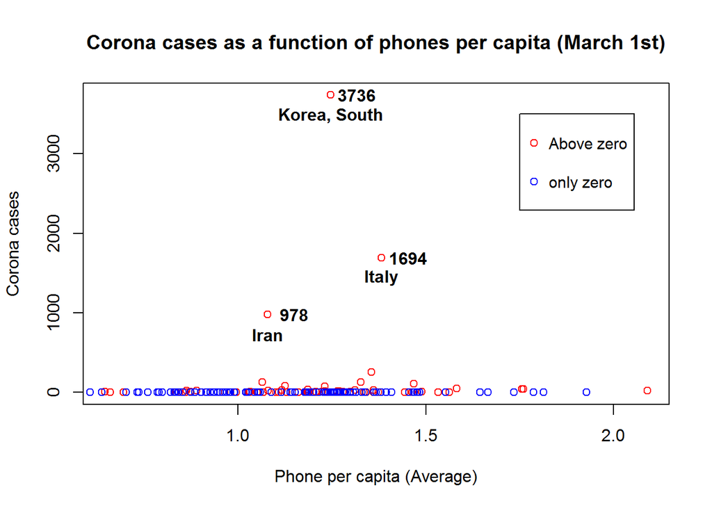

```r
plot(x = no_zero_cases$`phones per capita` , y = no_zero_cases$`Value (cases)`,
     col = "red", main = "Corona cases as a function of phones per capita (March 1st)",
     xlab = "Phone per capita (Average)",ylab= "Corona cases")
points(x = only_zero_cases$`phones per capita`, y = only_zero_cases$`Value (cases)`,
       col = "blue")
text(x = no_zero_cases$`phones per capita` + 0.07, y = no_zero_cases$`Value (cases)`,
     label = ifelse(no_zero_cases$`Value (cases)` > 600 , no_zero_cases$`Value (cases)`, NA),
     font = 2)
text(x = no_zero_cases$`phones per capita` , y = no_zero_cases$`Value (cases)`-250,
     label = ifelse(no_zero_cases$`Value (cases)` > 600 , no_zero_cases$country, NA),
     font = 2)

legend(x = 1.75, y = 3500, legend = c("Above zero", "only zero") ,pch = c(1,1),
       col = c("red","blue"),
       bty  = 'o', y.intersp = 2, xpd = T, cex = 0.95)
```

#### Higer resulotion of the countries with corona cases, low numbers:

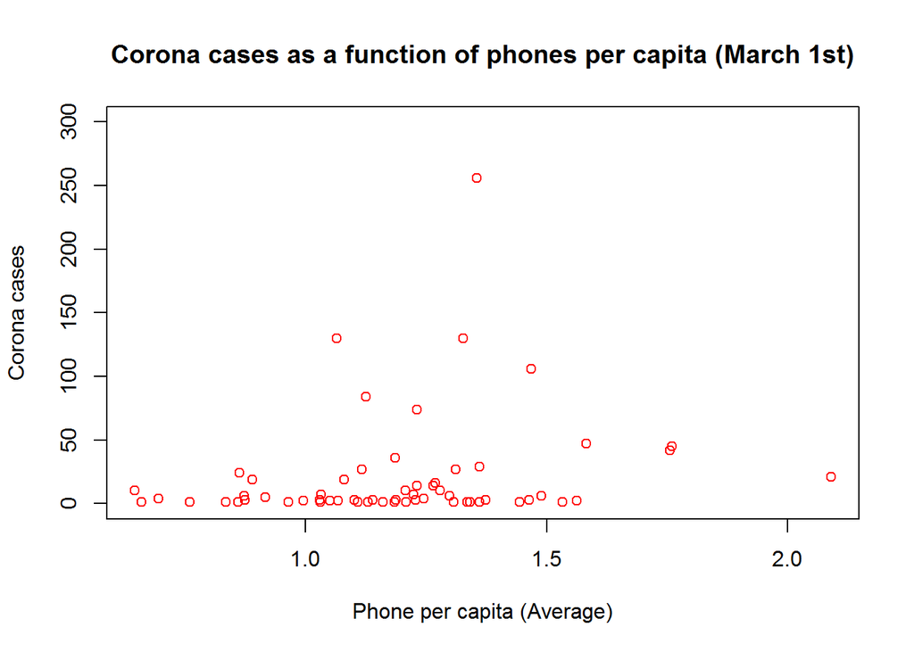

```r
plot(x = no_zero_cases$`phones per capita` , y = no_zero_cases$`Value (cases)`,
     col = "red", main = "Corona cases as a function of phones per capita (March 1st)",
     xlab = "Phone per capita (Average)",ylab= "Corona cases", ylim = c(0,300))
```

### conclusion:

**We can see that there is no effect of having a lot of cellular phones in a country. Assuming many phones could indicate a better flow of information, notifications and instructions - we thought that the more phones per capita in acountry, the more resistent it’d be against the corona in such date. After observing that the top countries have more than 1 phone per capita in average, we can conclude that there’s no impact on the quantity of phone on slowing down the spread.**

## Effect of health expenditure (% from GDP) - analysis:

**In this part we’d like to see how correlated the health expenditure of a country to the number of recovered and dead people. For that, we’ll look at the first day of April as a reference, knowing that at this day the virus was spread world wide and there was a large number of recovered and dead, as opposed to the first day of March**

### Effect of health expenditure (% from GDP) - general picture:

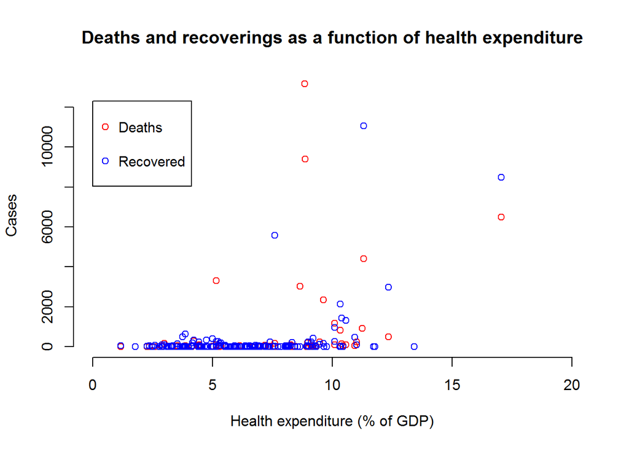

```r
#creating a relevan table:

april_first <- corona %>% filter(Date == "2020-04-01")
april_first <- inner_join(x = april_first, y = infrastructures, by= "country")
april_first <- filter(.data = april_first, is.na(april_first$health) == F)

plot(x = april_first$health , y = april_first$`Value (deaths)`,
     col = "red", main = "Deaths and recoverings as a function of health expenditure",
     xlab = "Health expenditure (% of GDP)" ,ylab= "Cases", frame.plot=FALSE,
     xlim = c(0, 20))

points(x = april_first$health, y = april_first$`Value (recovered)`,
       col = "blue")

legend(x = 0, y = 12300, legend = c("Deaths", "Recovered") ,pch = c(1,1),
       col = c("red","blue"),
       bty  = 'o', y.intersp = 2, xpd = T, cex = 0.95)
```

### Effect of health expenditure (% from GDP) - effect of death cases:

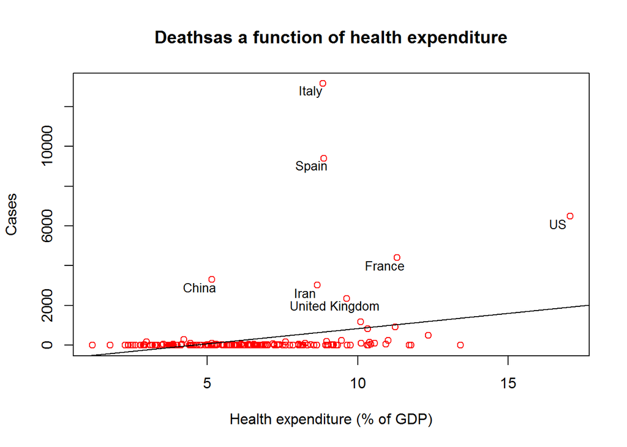

```r
plot(x = april_first$health , y = april_first$`Value (deaths)`,
     col = "red", main = "Deathsas a function of health expenditure",
     xlab = "Health expenditure (% of GDP)" ,ylab= "Cases")

abline(lm(april_first$`Value (deaths)` ~ april_first$health))

text(x = april_first$health -0.4, y = april_first$`Value (deaths)` - 400,
     label = ifelse(april_first$`Value (deaths)` > 2000 , april_first$country, NA),
      cex = 0.85)
```

```r
summary(lm(april_first$`Value (deaths)` ~ april_first$health))
```

```
##
## Call:
## lm(formula = april_first$`Value (deaths)` ~ april_first$health)
##
## Residuals:
##     Min      1Q  Median      3Q     Max
## -1359.1  -419.8  -204.9   100.0 12498.4
##
## Coefficients:
##                    Estimate Std. Error t value Pr(>|t|)
## (Intercept)         -699.11     281.10  -2.487 0.013856 *
## april_first$health   153.36      40.56   3.781 0.000217 ***
## ---
## Signif. codes:  0 '***' 0.001 '**' 0.01 '*' 0.05 '.' 0.1 ' ' 1
##
## Residual standard error: 1362 on 168 degrees of freedom
## Multiple R-squared:  0.07842,    Adjusted R-squared:  0.07294
## F-statistic:  14.3 on 1 and 168 DF,  p-value: 0.0002168
```

### Effect of health expenditure (% from GDP) - correlation with recoveries:

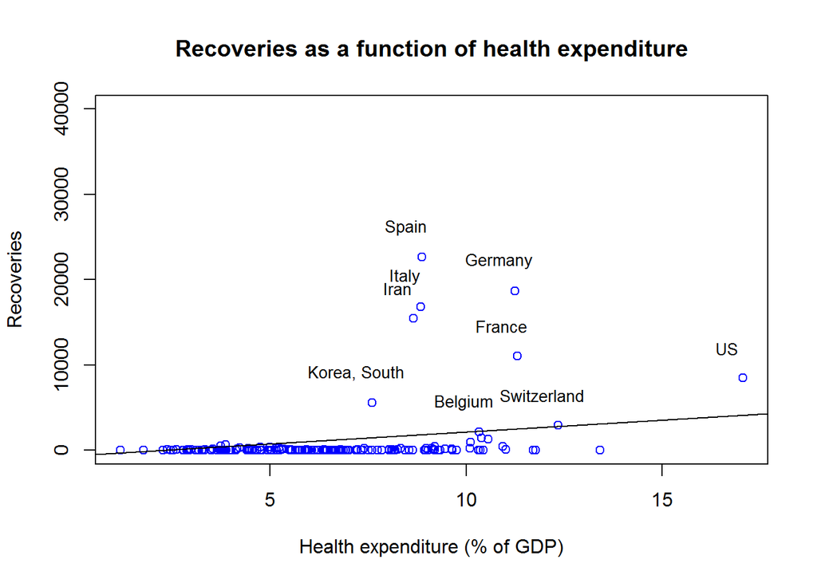

```r
plot(x = april_first$health , y = april_first$`Value (recovered)`,
     col = "blue", main = "Recoveries as a function of health expenditure",
     xlab = "Health expenditure (% of GDP)" ,ylab= "Recoveries", ylim = c(0,40000))

abline(lm(april_first$`Value (recovered)` ~ april_first$health))

text(x = april_first$health -0.4, y = april_first$`Value (recovered)` + 3500,
     label = ifelse(april_first$`Value (recovered)` > 2000 , april_first$country, NA),
      cex = 0.85)
```

```r
summary(lm(april_first$`Value (recovered)` ~ april_first$health))
```

```
##
## Call:
## lm(formula = april_first$`Value (recovered)` ~ april_first$health)
##
## Residuals:
##    Min     1Q Median     3Q    Max
##  -3068  -1365   -959   -381  75629
##
## Coefficients:
##                    Estimate Std. Error t value Pr(>|t|)
## (Intercept)          -651.1     1347.7  -0.483    0.630
## april_first$health    277.1      194.5   1.425    0.156
##
## Residual standard error: 6530 on 168 degrees of freedom
## Multiple R-squared:  0.01194,    Adjusted R-squared:  0.006063
## F-statistic: 2.031 on 1 and 168 DF,  p-value: 0.156
```

## Effect of access to electricity (% of population) - analysis:

**In this part we’d like to see how the accessibility to electricity affects the deaths. Assuming that focusing on the recoveries can neglegt the number of alive but sick people, we’d like to see if there’s a negative correlation between access to electricity and mortality**

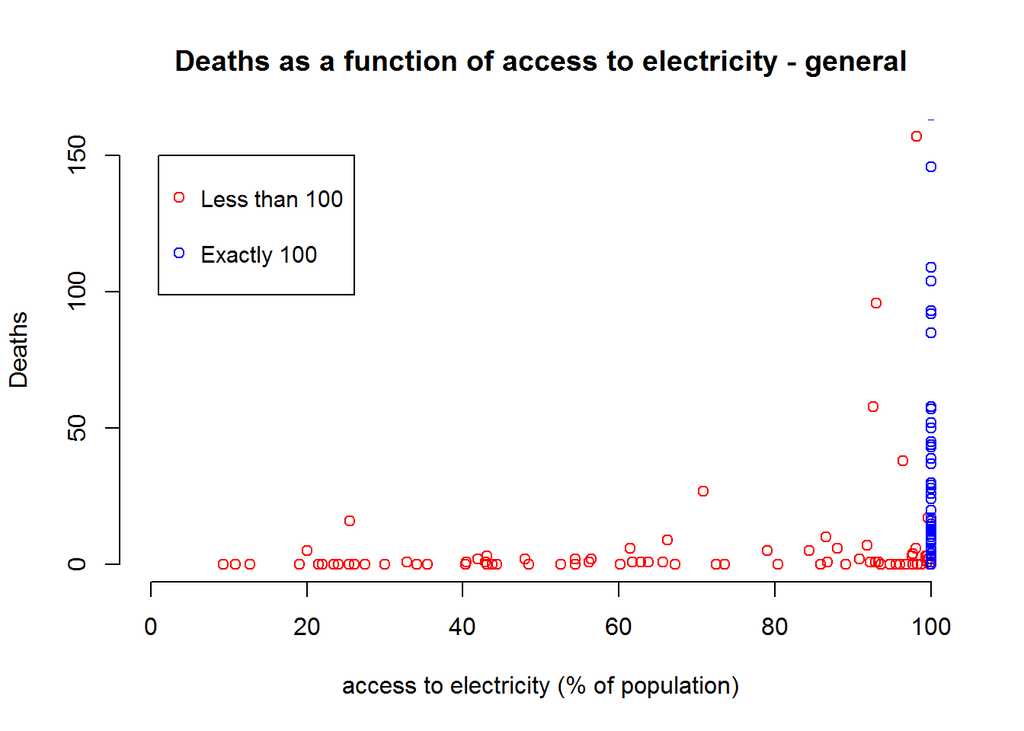

```r
april_100 <- filter(.data = april_first, electricity == 100)
april_less_100 <- filter(.data = april_first, electricity < 100)

plot(x = april_less_100$electricity , y = april_less_100$`Value (deaths)`,
     col = "red", main = "Deaths as a function of access to electricity - general",
     xlab = "access to electricity (% of population)" ,ylab= "Deaths", frame.plot=FALSE,
     xlim = c(0,100))

points(x = april_100$electricity, y = april_100$`Value (deaths)`,
       col = "blue")

legend(x = 1, y = 150, legend = c("Less than 100", "Exactly 100") ,pch = c(1,1),
       col = c("red","blue"),
       bty  = 'o', y.intersp = 2, xpd = T, cex = 0.95)
```

### Effect of access to electricity (% of population) - less than 100:

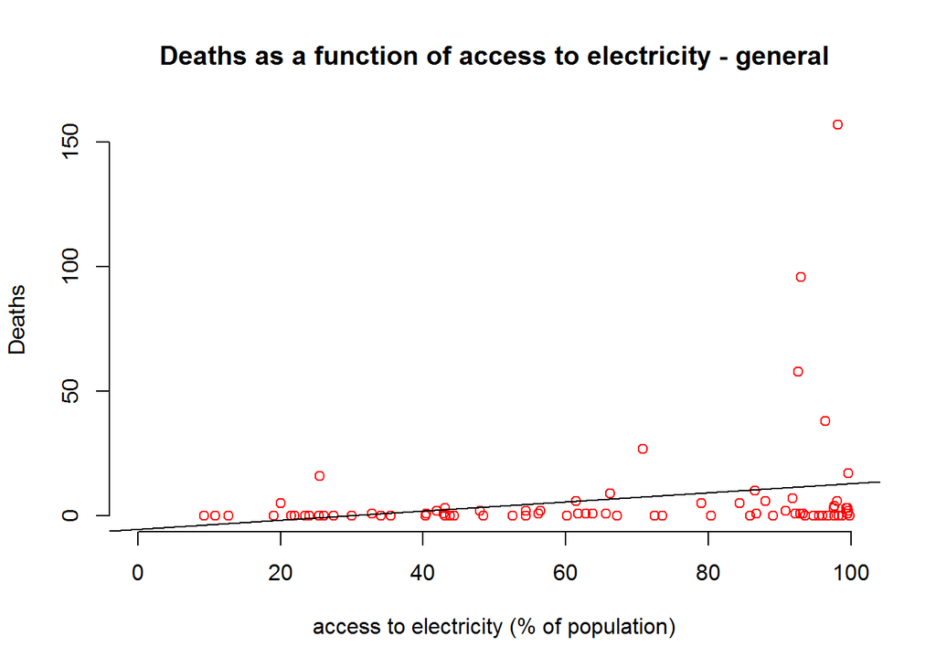

```r
plot(x = april_less_100$electricity , y = april_less_100$`Value (deaths)`,
     col = "red", main = "Deaths as a function of access to electricity - general",
     xlab = "access to electricity (% of population)" ,ylab= "Deaths", frame.plot=FALSE,
     xlim = c(0,100))

abline(lm(april_less_100$`Value (deaths)` ~ april_less_100$electricity))
```

```r
summary(lm(april_less_100$`Value (deaths)` ~ april_less_100$electricity))
```

```
##
## Call:
## lm(formula = april_less_100$`Value (deaths)` ~ april_less_100$electricity)
##
## Residuals:
##     Min      1Q  Median      3Q     Max
## -12.941  -9.528  -3.969   0.428 144.363
##
## Coefficients:
##                            Estimate Std. Error t value Pr(>|t|)
## (Intercept)                -5.30620    6.05936  -0.876   0.3840
## april_less_100$electricity  0.18283    0.08497   2.152   0.0346 *
## ---
## Signif. codes:  0 '***' 0.001 '**' 0.01 '*' 0.05 '.' 0.1 ' ' 1
##
## Residual standard error: 21.58 on 75 degrees of freedom
## Multiple R-squared:  0.05815,    Adjusted R-squared:  0.04559
## F-statistic:  4.63 on 1 and 75 DF,  p-value: 0.03463
```

### Effect of access to electricity (% of population) - 100% access:

**In this section we’ll look at the histogram of the deaths, since all of the access values are 100. We’d like to assume that most of the cases will be concetrated around 0, on low values, since we believe access to electricity helps prevent mortality: by health care in hospitals, by communication, etc.**

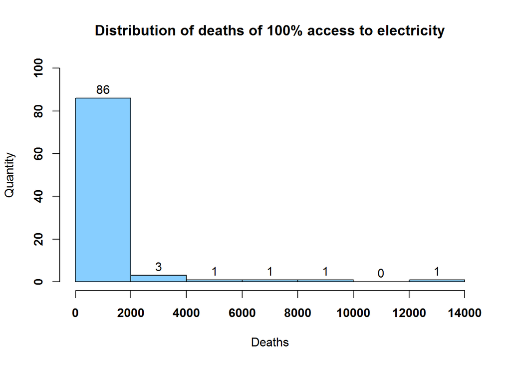

```r
deaths_hist <- hist(x = april_100$`Value (deaths)`,
     breaks = seq(from = 0, to = 14000, by =2000),
     main = "Distribution of deaths of 100% access to electricity",
     ylim = c(0,100), xlab = "Deaths", ylab = "Quantity",
     col = "skyblue1", cex = 0.8, labels = T, font = 2)
```

**Since there’s no standart deviation, we cant talk about correlations and regressions, but we can still see that our prediction was pretty much accurate. Although we cant assume there’s causality, we can see a link between 100% access to electricity, and somewhat low-rate mortality.**